# Homework 04

Salomon Gilles - Credit to Andrew Abbott for inspiring me

May 31, 2016

## Introduction:

We attempt to illustrate the Central Limit Theorem using R markdown and push it it to GitHub. We use a normal distribution with two different sample sizes and an exponential distribution with two different sample sizes.

### 1: Normal Distribution: samplesize = 150 and simulation = 1100

```r
n1 <- 150
nsimulations1 <- 1100
basepool1 <- rnorm(n1)
means.array1 <- numeric(nsimulations1)
for (index in 1:nsimulations1) {
        tempvar1 <- sample(basepool1, size = length(basepool1), replace = TRUE)
    means.array1[index] <- mean(tempvar1)
}
```

## Original pool1

```r
summary(basepool1)
```

```
##      Min.   1st Qu.    Median      Mean   3rd Qu.      Max.
## -3.121000 -0.633600 -0.027640  0.008025  0.699100  3.048000
```

We can see that difference in distortions with the severity on either side

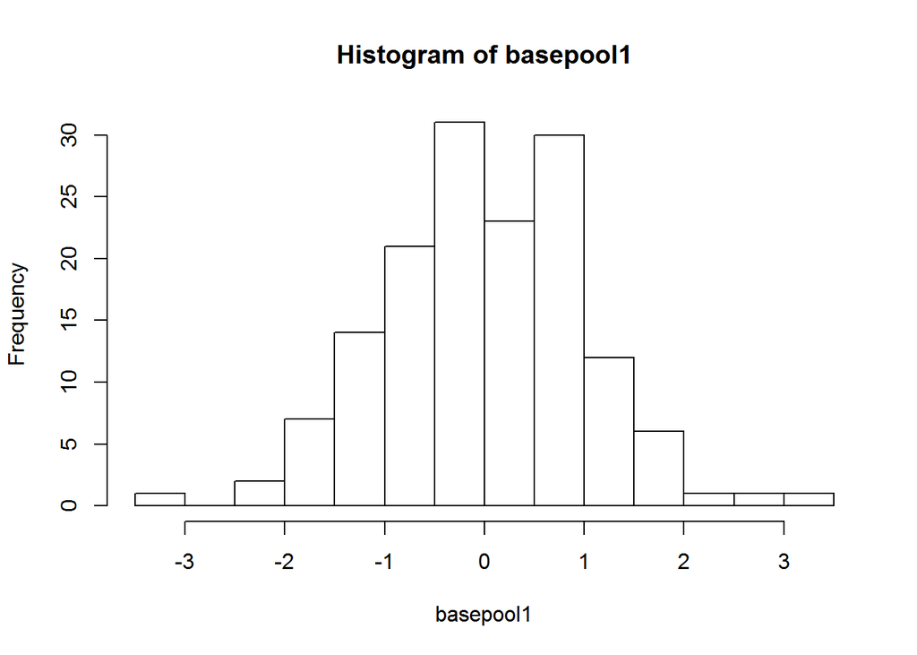

```r
hist(basepool1)
```

## Means array

Notice the median and the mean are approximately equally distributed on the summary table

```r
summary(means.array1)
```

```
##     Min.  1st Qu.   Median     Mean  3rd Qu.     Max.
## -0.25780 -0.04235  0.01086  0.01159  0.06474  0.36220
```

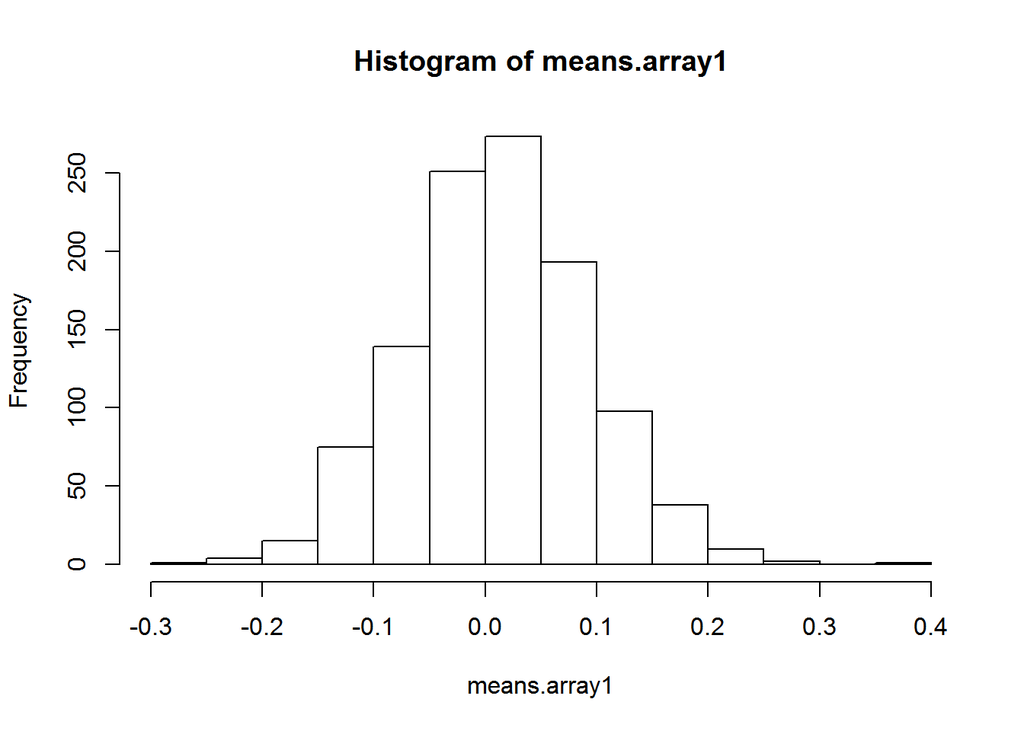

```r
hist(means.array1)
```

### 2: Normal Distribution: samplesize = 1100 and simulation = 1100

```r
n2 <- 1100
nsimulations2 <- 1100
basepool2 <- rnorm(n2)
means.array2 <- numeric(nsimulations2)
for (index in 1:nsimulations2) {
        tempvar2 <- sample(basepool2, size = length(basepool2), replace = TRUE)
    means.array2[index] <- mean(tempvar2)
}
```

## Original pool2

```r
summary(basepool2)
```

```
##     Min.  1st Qu.   Median     Mean  3rd Qu.     Max.
## -2.82400 -0.63920  0.02540  0.03657  0.72530  3.71600
```

We can see that difference in distortions with the severity on either side

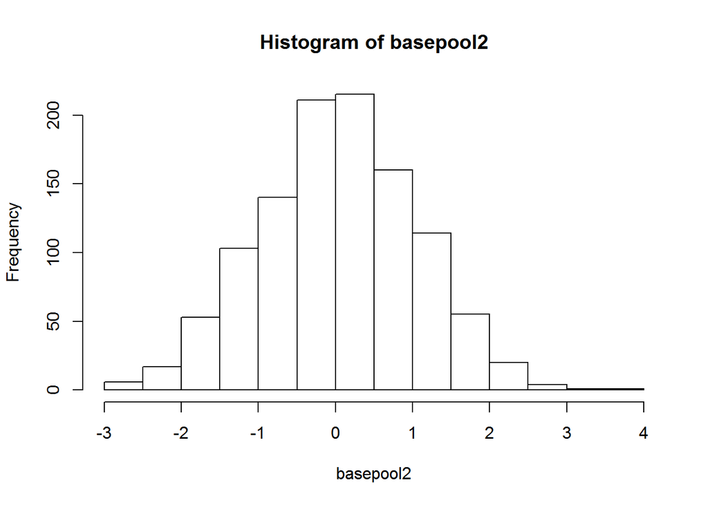

```r
hist(basepool2)
```

## Means array2

Notice the median and the mean are still approximately closely distributed on the summary table

```r
summary(means.array2)
```

```
##     Min.  1st Qu.   Median     Mean  3rd Qu.     Max.
## -0.06172  0.01511  0.03583  0.03546  0.05656  0.13190
```

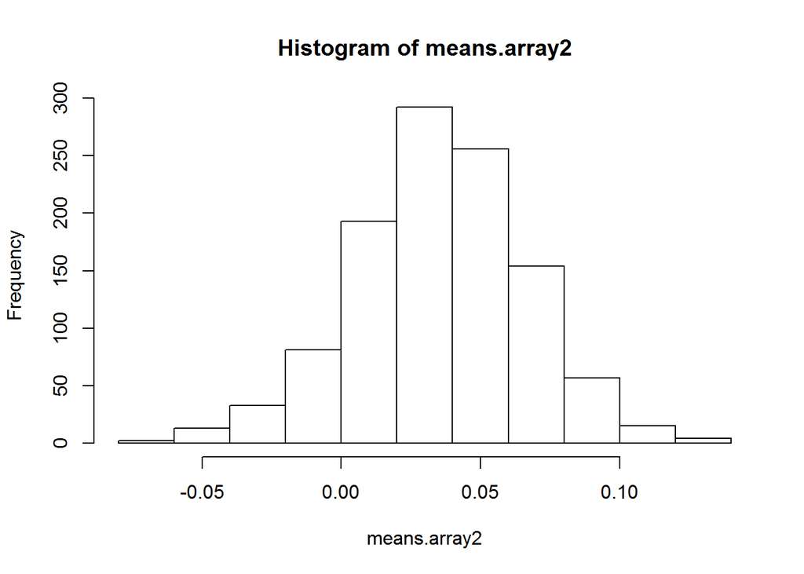

```r
hist(means.array2)
```

### 3: Exponential Distribution: samplesize = 150 and simulation = 1100

```r
n3 <- 150
nsimulations3 <- 1100
basepool3 <- rexp(n3)
means.array3 <- numeric(nsimulations3)
for (index in 1:nsimulations3) {
        tempvar3 <- sample(basepool3, size = length(basepool3), replace = TRUE)
    means.array3[index] <- mean(tempvar3)
}
```

## Original pool3

The median and the mean are very far apart with only the right skewed

```r
summary(basepool3)
```

```
##    Min. 1st Qu.  Median    Mean 3rd Qu.    Max.
## 0.01021 0.32510 0.66980 0.90070 1.21700 6.01100
```

We can see that difference in distortions with the severity only on the right side

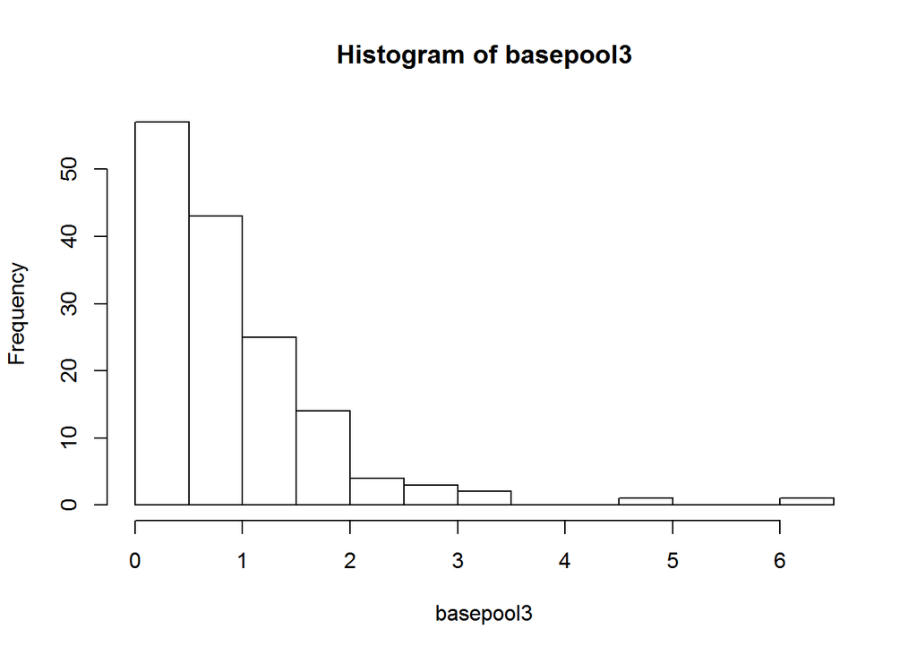

```r
hist(basepool3)
```

## Means array3

Notice the median and the mean are approximately equally distributed on the summary table

```r
summary(means.array3)
```

```
##    Min. 1st Qu.  Median    Mean 3rd Qu.    Max.
##  0.6896  0.8576  0.9001  0.9045  0.9524  1.1480
```

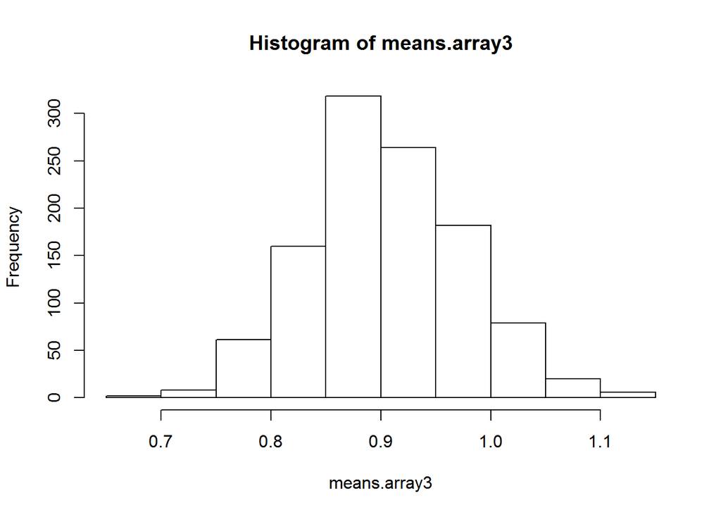

```r
hist(means.array3)
```

### 4: Exponential Distribution: samplesize = 1100 and simulation = 1100

```r
n4 <- 1100
nsimulations4 <- 1100
basepool4 <- rexp(n4)
means.array4 <- numeric(nsimulations4)
for (index in 1:nsimulations4) {
        tempvar4 <- sample(basepool4, size = length(basepool4), replace = TRUE)
    means.array4[index] <- mean(tempvar4)
}
```